# Data Wrangling Project

Jyoti Chaudhary

December 6, 2016

```r
nat_salary <- read_excel("National_salary.xlsx", na="", col_names = TRUE, col_types = NULL)

colnames(nat_salary) <- c("Code", "Job.title", "Group", "Emp.count", "Emp.PRSE", "Mean.hourly.wage", "Mean.annual.wage", "Mean.PRSE", "H.PCT10", "H.PCT25", "Median.hourly.wage", "H.PCT75", "H.PCT90", "A.PCT10", "A.PCT25", "Annual.median.wage", "A.PCT75", "A.PCT90", "Annual", "Hourly")

## Change numberic fields from 'character' class to 'numeric' class ##################

nat_salary$Mean.hourly.wage <- fround(as.numeric(nat_salary$Mean.hourly.wage), 2)
nat_salary$Median.hourly.wage <- fround(as.numeric(nat_salary$Median.hourly.wage), 2)
nat_salary$H.PCT10 <- fround(as.numeric(nat_salary$H.PCT10), 2)
nat_salary$H.PCT25 <- fround(as.numeric(nat_salary$H.PCT25), 2)
nat_salary$H.PCT75 <- fround(as.numeric(nat_salary$H.PCT75), 2)
nat_salary$H.PCT90 <- fround(as.numeric(nat_salary$H.PCT90), 2)
nat_salary$A.PCT10 <- fround(as.numeric(nat_salary$A.PCT10), 2)
nat_salary$A.PCT25 <- fround(as.numeric(nat_salary$A.PCT25), 2)
nat_salary$A.PCT75 <- fround(as.numeric(nat_salary$A.PCT75), 2)
nat_salary$A.PCT90 <- fround(as.numeric(nat_salary$A.PCT90), 2)
nat_salary <- nat_salary %>% mutate(code2 = substr(nat_salary$Code, 1, 2), major = "")

nat_salary$major <- ifelse(nat_salary$code2 == "11", c("Management"), nat_salary$major)
nat_salary$major <- ifelse(nat_salary$code2 == "13", c("Business and Financial Operations"), nat_salary$major)
nat_salary$major <- ifelse(nat_salary$code2 == "15", c("Computer and Mathematical"), nat_salary$major)
nat_salary$major <- ifelse(nat_salary$code2 == "17", c("Architecture and Engineering Occupations"), nat_salary$major)
nat_salary$major <- ifelse(nat_salary$code2 == "19", c("Life, Physical, and Social Science"), nat_salary$major)
nat_salary$major <- ifelse(nat_salary$code2 == "21", c("Community and Social Service"), nat_salary$major)
nat_salary$major <- ifelse(nat_salary$code2 == "23", c("Legal"), nat_salary$major)

nat_salary$major <- ifelse(nat_salary$code2 == "25", c("Education, Training, and Library"), nat_salary$major)
nat_salary$major <- ifelse(nat_salary$code2 == "27", c("Arts, Design, Entertainment, Sports, and Media"), nat_salary$major)
nat_salary$major <- ifelse(nat_salary$code2 == "29", c("Healthcare Practitioners"), nat_salary$major)
nat_salary$major <- ifelse(nat_salary$code2 == "31", c("Healthcare Support"), nat_salary$major)
nat_salary$major <- ifelse(nat_salary$code2 == "33", c("Protective Service"), nat_salary$major)
nat_salary$major <- ifelse(nat_salary$code2 == "35", c("Food Preparation and Serving"), nat_salary$major)
nat_salary$major <- ifelse(nat_salary$code2 == "37", c("Building and Grounds Cleaning and Maintenance"), nat_salary$major)
nat_salary$major <- ifelse(nat_salary$code2 == "39", c("Personal Care and Service"), nat_salary$major)
nat_salary$major <- ifelse(nat_salary$code2 == "41", c("Sales and Related"), nat_salary$major)
nat_salary$major <- ifelse(nat_salary$code2 == "43", c("Office and Administrative Support"), nat_salary$major)
nat_salary$major <- ifelse(nat_salary$code2 == "45", c("Farming, Fishing, and Forestry"), nat_salary$major)
nat_salary$major <- ifelse(nat_salary$code2 == "47", c("Construction and Extraction"), nat_salary$major)
nat_salary$major <- ifelse(nat_salary$code2 == "49", c("Installation, Maintenance, and Repair"), nat_salary$major)
nat_salary$major <- ifelse(nat_salary$code2 == "51", c("Production"), nat_salary$major)
nat_salary$major <- ifelse(nat_salary$code2 == "53", c("Transportation and Material Moving"), nat_salary$major)
```

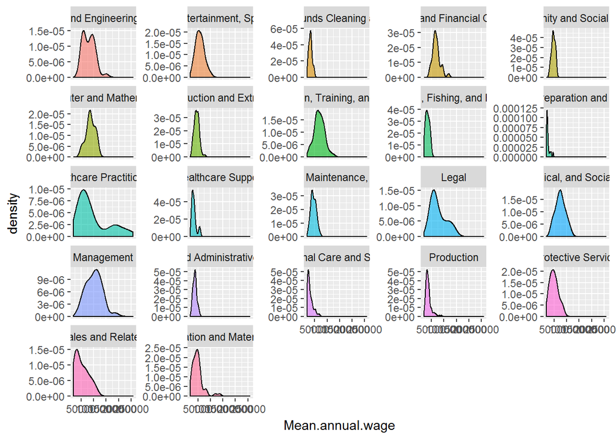

```r
salary_major_detail %>% filter(Group != 'major') %>%
  ggplot(aes(x = Mean.annual.wage)) +
 geom_density(aes(fill = major), alpha = 0.6) +
  facet_wrap(~major, scales="free_y") + theme(legend.position="none")
```

[output not shown]

[output not shown]

BOXPLOT FOR SALARY RANGE OF TOP PAYING OCCUPATIONS: Anesthesiologists, Chief Executives and Family and General Practitioners

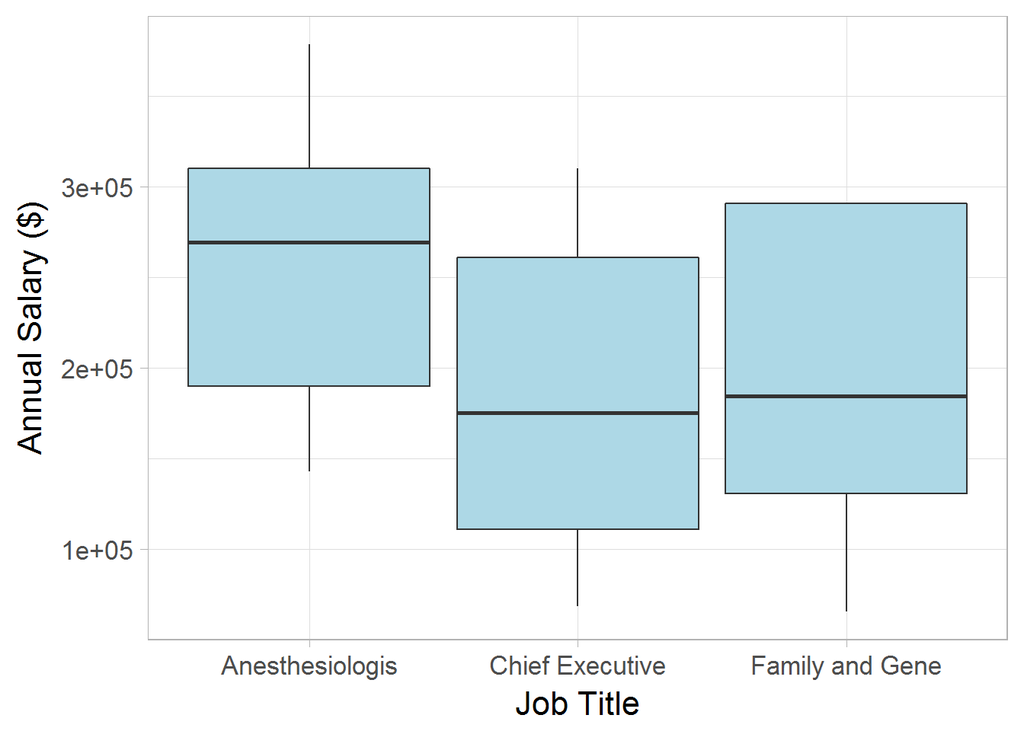

```r
ggplot(top_low_salary[1:3,], aes(Job.title)) +
  geom_boxplot(fill="lightblue",
    aes(ymin = A.PCT10, lower = A.PCT25, middle = Annual.median.wage, upper = A.PCT75, ymax = A.PCT90),
    stat = "identity") + theme_light(base_size=16) + ylab("Annual Salary ($)") + xlab("Job Title")
```

BOXPLOT FOR SALARY RANGE OF LOWEST PAYING OCCUPATIONS

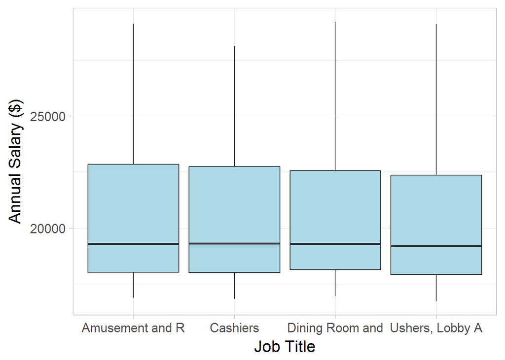

```r
ggplot(top_low_salary[4:7,], aes(Job.title)) +
  geom_boxplot(fill="lightblue",
    aes(ymin = A.PCT10, lower = A.PCT25, middle = Annual.median.wage, upper = A.PCT75, ymax = A.PCT90),
    stat = "identity"
  ) + theme_light(base_size=16) + ylab("Annual Salary ($)") + xlab("Job Title")
```

Load excel data sheet “state_May2015_dl.xlsx” into R. This data sheet has US income wage data, by State, for all major occupations. The code extracts the salary details of major occupations and will plot a Horizontal Bar graph for total employment count by state.

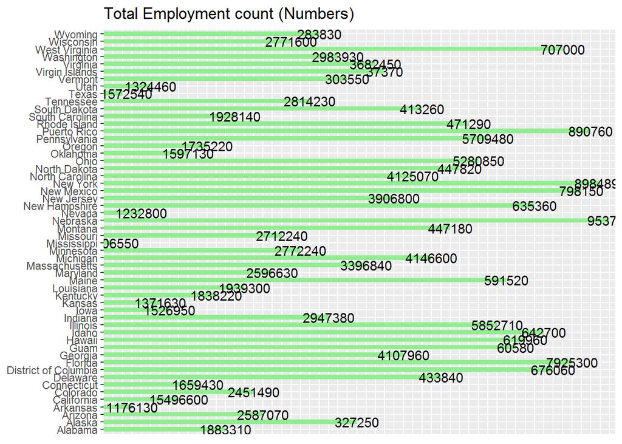

```r
## Bar plot to show total employment count
state_salary2 <- state_salary1 %>% filter(Group=='total')

ggplot(state_salary2, aes(State, Emp.count)) + geom_bar(aes(fill=Emp.count), stat = "identity", width = 0.6, fill = "lightgreen") + geom_text(label = state_salary2$Emp.count) + coord_flip() + ggtitle("Total Employment count (Numbers)" ) + xlab(NULL) + ylab(NULL) + theme(axis.title.x=element_blank(), axis.text.x=element_blank(), axis.ticks.x=element_blank())
```

Choropleth for US Annual Mean Salary, 2015, by STATE

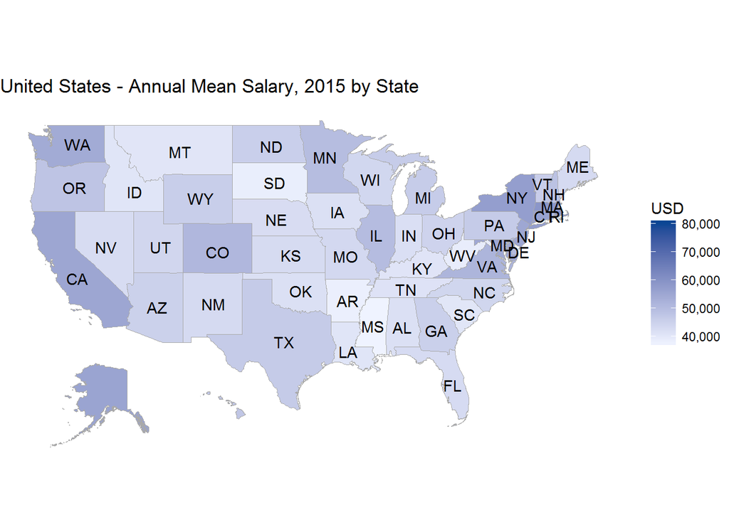

```r
# removed 3 states as they are not mapped in choropleth
State_salary_choro <- state_salary2 %>% filter(State != "Guam" & State != "Puerto Rico" & State != "Virgin Islands") %>% select(State, A.mean.wage)

State_salary_choro$A.mean.wage <- as.numeric(State_salary_choro$A.mean.wage)
colnames(State_salary_choro) <- c("region", "value")
State_salary_choro$region <- str_to_lower(State_salary_choro$region)
state_choropleth(State_salary_choro,
                 title  = "United States - Annual Mean Salary, 2015 by State",
                 legend = "USD", num_colors = 1)
```

Load excel data sheet “US_Crime_2015” into R. This data sheet has US Crime data for various crime categories. The code converts the data into tall format using ‘GATHER’ command and plots a bar graph with States plotted on X axis and crime incident count for each crime category plotted on Y axis.

[output not shown]

Converted Crime data frame into tall format using GATHER. This is needed to plot crime count by category.

```r
tall_crime_count <- gather(crime_file5, key="crime.category", 2:10, value = "count")

tall_crime_rate <- gather(crime_file6, key="crime.category", 2:10, value = "rate")
```

2015 CRIME INCIDENT COUNT PLOTTED ON Y-AXIS AND BAR IS PLOTTED FOR EACH STATE ON X-AXIS

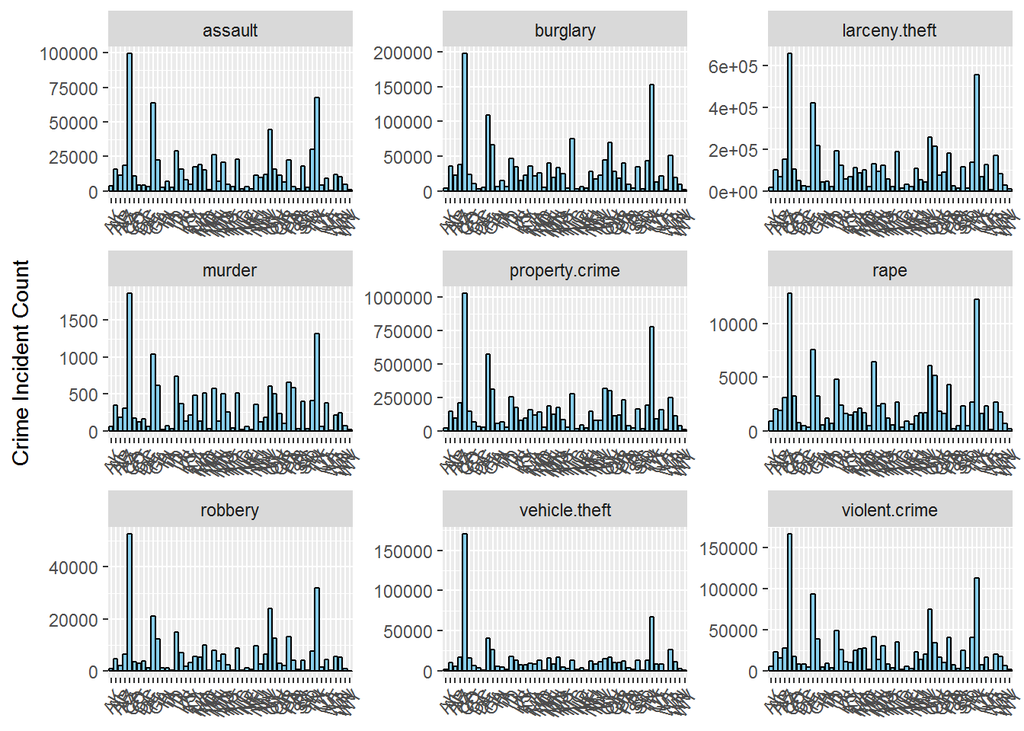

```r
ggplot(tall_crime_count, aes(state.code, count)) +
  geom_bar(aes(fill = count), stat = "identity", colour="black", fill="skyblue") +
  ylab('Crime Incident Count') + xlab(NULL) +
  facet_wrap(~crime.category, scales='free') + theme(axis.text.x = element_text(angle=60, hjust=1))
```

2015 CRIME RATE (PER 100,000) PLOTTED ON Y-AXIS AND BAR IS PLOTTED FOR EACH STATE ON X-AXIS

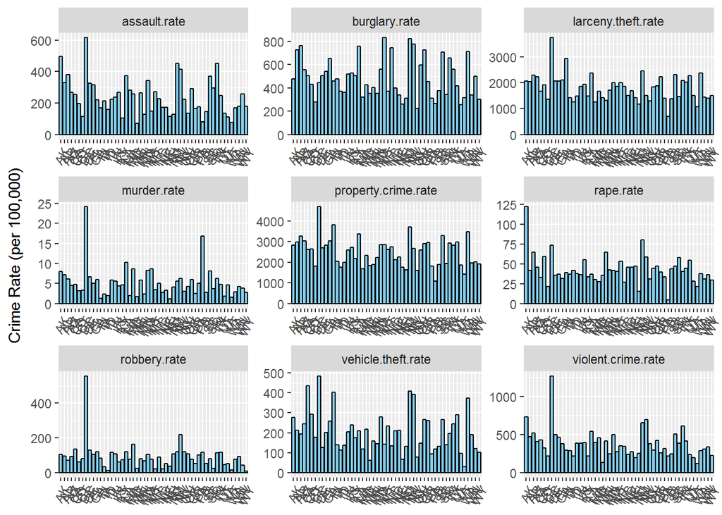

```r
ggplot(tall_crime_rate, aes(state.code, rate)) +
  geom_bar(aes(fill = rate), stat = "identity", colour="black", fill="skyblue") +
  ylab('Crime Rate (per 100,000)') + xlab(NULL) +
  facet_wrap(~crime.category, scales='free') + theme(axis.text.x = element_text(angle=60, hjust=1))
```